# UTS Regresi

Muhammad Adi Nur Kholifah

2025-05-07

# Soal 1

## Langkah 1 Buat Correlation Matrix

```r
# Load library
library(ggplot2)
library(reshape2)
library(corrplot)
library(RColorBrewer)

# Load dataset
data <- read.csv("HeatingOil.csv")

# Tampilkan beberapa baris pertama
head(data)
```

|  | Insulation | Temperature | Heating_Oil | Num_Occupants | Avg_Age | Home_Size |
| --- | --- | --- | --- | --- | --- | --- |
| 1 | 6 | 74 | 132 | 4 | 23.8 | 4 |
| 2 | 10 | 43 | 263 | 4 | 56.7 | 4 |
| 3 | 3 | 81 | 145 | 2 | 28.0 | 6 |
| 4 | 9 | 50 | 196 | 4 | 45.1 | 3 |
| 5 | 2 | 80 | 131 | 5 | 20.8 | 2 |
| 6 | 5 | 76 | 129 | 3 | 21.5 | 3 |

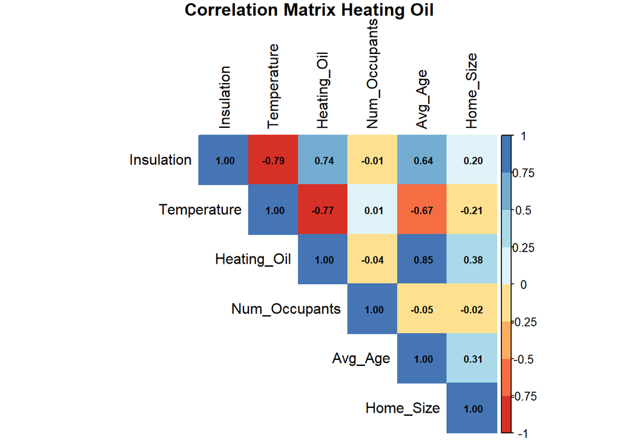

```r
# Hitung korelasi
cor_matrix <- cor(data)

# Tampilkan matriks korelasi sebagai heatmap
corrplot(cor_matrix, method = "color", type = "upper",
         col = brewer.pal(n = 8, name = "RdYlBu"),
         tl.col = "black", addCoef.col = "black",
         number.cex = 0.7, mar = c(0,0,1,0),
         title = "Correlation Matrix Heating Oil")
```

## Langkah 2: Interpretasi Korelasi

Kita melihat bahwa:

- Avg_Age memiliki korelasi positif sangat kuat dengan Heating_Oil (0.85)
- Insulation juga berkorelasi positif cukup kuat (0.74)
- Temperature berkorelasi negatif kuat dengan Heating_Oil (-0.77)
- Home_Size memiliki korelasi sedang (0.38)
- Num_Occupants hampir tidak ada korelasi (-0.04)

Kesimpulan: Faktor usia penghuni, suhu udara, dan insulasi rumah paling memengaruhi konsumsi Heating_Oil.

## Langkah 3 Scatter Plot 1

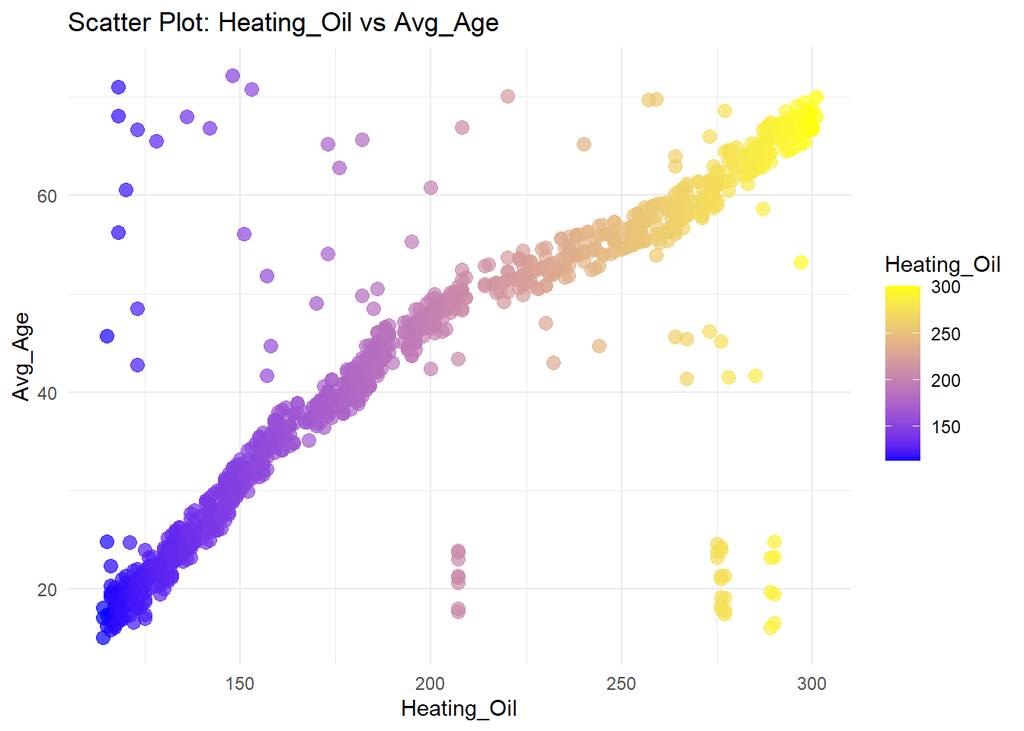

```r
ggplot(data, aes(x = Heating_Oil, y = Avg_Age, color = Heating_Oil)) +
  geom_point(alpha = 0.7, size = 3) +
  scale_color_gradient(low = "blue", high = "yellow") +
  theme_minimal() +
  labs(title = "Scatter Plot: Heating_Oil vs Avg_Age",
       x = "Heating_Oil",
       y = "Avg_Age",
       color = "Heating_Oil")
```

### Interpretasi Scatter Plot 1

Scatter plot ini menunjukkan hubungan antara jumlah konsumsi Heating_Oil dan usia rata-rata penghuni rumah. Dari visualisasi:

- Titik-titik dengan warna lebih cerah (kuning) menunjukkan konsumsi Heating_Oil yang tinggi.
- Terlihat bahwa semakin tinggi rata-rata usia penghuni rumah, cenderung konsumsi Heating_Oil juga meningkat.
- Ini bisa diartikan bahwa rumah yang dihuni oleh orang yang lebih tua menggunakan lebih banyak minyak pemanas, kemungkinan karena mereka membutuhkan kenyamanan termal yang lebih stabil atau menghabiskan lebih banyak waktu di rumah.

# Langkah 4: Scatter Plot 2

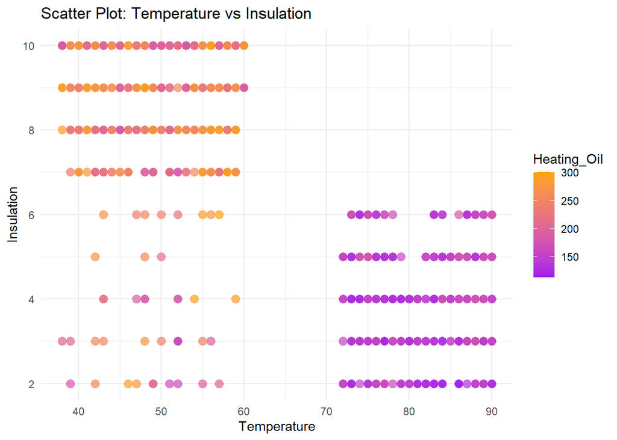

```r
ggplot(data, aes(x = Temperature, y = Insulation, color = Heating_Oil)) +
  geom_point(alpha = 0.7, size = 3) +
  scale_color_gradient(low = "purple", high = "orange") +
  theme_minimal() +
  labs(title = "Scatter Plot: Temperature vs Insulation",
       x = "Temperature",
       y = "Insulation",
       color = "Heating_Oil")
```

### Interpretasi Scatter Plot 2

Scatter plot ini memperlihatkan hubungan antara rata-rata suhu udara luar dan skor insulasi rumah, dengan warna mewakili intensitas konsumsi Heating_Oil.

- Titik-titik dengan warna oranye (nilai tinggi) banyak ditemukan pada bagian suhu rendah dan insulasi sedang hingga tinggi.
- Rumah di wilayah dengan suhu lebih rendah cenderung tetap mengonsumsi banyak Heating_Oil, meskipun insulasinya bagus.
- Sementara itu, pada suhu yang lebih hangat, konsumsi Heating_Oil cenderung rendah meskipun insulasi rumah bervariasi.

## Langkah 5: Rekomendasi Strategi Pemasaran

Target Pelanggan:

- Fokus pada rumah dengan penghuni lebih tua dan daerah dengan suhu lebih rendah.

Promosi:

- Berikan diskon khusus untuk rumah dengan insulasi baik tapi tetap konsumsi tinggi.
- Tawarkan paket edukasi & subsidi peningkatan insulasi untuk pelanggan dengan konsumsi tinggi dan insulasi buruk.

Komunikasi:

- Gunakan data lokal suhu dan usia penghuni untuk personalisasi penawaran.

# Soal 2

#### Untuk Sarah (VP Marketing): Buat dan Simpan Model Prediksi

## 1 Membaca Data Rahasia

```r
# Library
library(readr)

# Baca data rahasia
data <- read_csv("HeatingOil.csv")
head(data)
```

| Insulation | Temperature | Heating_Oil | Num_Occupants | Avg_Age | Home_Size |
| --- | --- | --- | --- | --- | --- |
| 6 | 74 | 132 | 4 | 23.8 | 4 |
| 10 | 43 | 263 | 4 | 56.7 | 4 |
| 3 | 81 | 145 | 2 | 28.0 | 6 |
| 9 | 50 | 196 | 4 | 45.1 | 3 |
| 2 | 80 | 131 | 5 | 20.8 | 2 |
| 5 | 76 | 129 | 3 | 21.5 | 3 |

## 2 Membuat Model Regresi

```r
# Library
library(caret)
```

```r
# Buat model regresi linear
model <- lm(Heating_Oil ~ Insulation + Temperature + Num_Occupants + Avg_Age + Home_Size, data = data)

# Ringkasan model
summary(model)
```

```
##
## Call:
## lm(formula = Heating_Oil ~ Insulation + Temperature + Num_Occupants +
##     Avg_Age + Home_Size, data = data)
##
## Residuals:
##      Min       1Q   Median       3Q      Max
## -103.558  -11.999    0.544   11.764  128.215
##
## Coefficients:
##                Estimate Std. Error t value Pr(>|t|)
## (Intercept)   135.48094    7.73091  17.525  < 2e-16 ***
## Insulation      3.32551    0.42044   7.910 5.78e-15 ***
## Temperature    -0.86993    0.07114 -12.228  < 2e-16 ***
## Num_Occupants  -0.26896    0.40689  -0.661    0.509
## Avg_Age         1.96582    0.06523  30.137  < 2e-16 ***
## Home_Size       3.17151    0.31088  10.202  < 2e-16 ***
## ---
## Signif. codes:  0 '***' 0.001 '**' 0.01 '*' 0.05 '.' 0.1 ' ' 1
##
## Residual standard error: 23.96 on 1212 degrees of freedom
## Multiple R-squared:  0.8193, Adjusted R-squared:  0.8186
## F-statistic:  1099 on 5 and 1212 DF,  p-value: < 2.2e-16
```

## 3 Simpan Model ke File

```r
# Simpan model ke file .RDS agar bisa dibagikan
saveRDS(model, file = "model_heating_oil.rds")
```

Catatan: Hanya file model_heating_oil.rds yang akan dikirim ke para marketer, tanpa menyertakan data mentah HeatingOil.csv.

#### Untuk Marketer: Menggunakan Model untuk Prediksi

## 1 Load Model dari Sarah

```r
# Library
library(readr)

# Load model yang dikirim oleh Sarah
model <- readRDS("model_heating_oil.rds")
```

## 2 Baca Data Calon Pelanggan Baru

```r
# Baca data calon pelanggan
data_new <- read_csv("HeatingOil-Marketing.csv")
head(data_new)
```

| Insulation | Temperature | Num_Occupants | Avg_Age | Home_Size |
| --- | --- | --- | --- | --- |
| 6 | 74 | 4 | 23.8 | 4 |
| 10 | 43 | 4 | 56.7 | 4 |
| 3 | 81 | 2 | 28.0 | 6 |
| 9 | 50 | 4 | 45.1 | 3 |

## 3 Prediksi Kebutuhan Minyak

```r
# Prediksi menggunakan model
prediksi <- predict(model, newdata = data_new)

# Tambahkan hasil prediksi ke data
data_new$Predicted_Heating_Oil <- prediksi

# Lihat hasil
head(data_new)
```

| Insulation | Temperature | Num_Occupants | Avg_Age | Home_Size | Predicted_Heating_Oil |
| --- | --- | --- | --- | --- | --- |
| 6 | 74 | 4 | 23.8 | 4 | 149.4560 |
| 10 | 43 | 4 | 56.7 | 4 | 254.4012 |
| 3 | 81 | 2 | 28.0 | 6 | 148.5274 |
| 9 | 50 | 4 | 45.1 | 3 | 219.0112 |